# Inference on Coefficients: Confidence Intervals

Dr. Josh Jacobson

26 January 2026

*These lecture notes were originally developed by Dr. Kris Pruitt.*

The purpose of this lesson is to demonstrate computational and mathematical methods for constructing confidence intervals for the slope parameter of a simple linear regression model.

# Computational Confidence Interval

Earlier in the course, we derived a point estimate for the slope parameter of the following simple linear regression model.

$$y=\beta_0+\beta_1x+\epsilon$$

When fitting a regression model using sample data, the slope is a statistic intended to estimate the true slope in the population. Thus, we are estimating a population parameter, just like any other. In the previous lesson, we completed hypothesis tests to evaluate evidence that the slope differed from zero. But such tests only suggest what the slope is *not* rather than what it *is*. In order to obtain a range of likely values for the slope parameter, we need to construct a confidence interval.

For this example, we once again use a data set regarding the gestation period of babies from the early 1960s. The study associated with this data was originally conducted to research the impact of the mother’s smoking habits on the health of the baby. Load the required packages and import the `Gestation` data frame.

```r
# load packages
library(mosaicData)

# import data
data(Gestation)
```

Suppose we are interested in the association between gestation period (months) and birth weight (pounds). We’ll begin by wrangling the data and visualizing the association in a scatter plot.

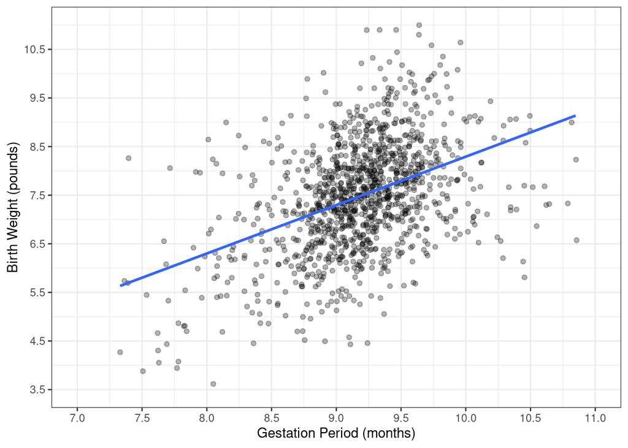

```r
# wrangle data
births <- Gestation %>%
  transmute(
    months = gestation / 30.42,
    weight = wt / 16
  ) %>%
  na.omit() %>%
  filter(months > 7, months < 11)

# plot gestation versus weight
ggplot(data = births, aes(x = months, y = weight)) +
  geom_point(position = "jitter", alpha = 0.3) +
  geom_smooth(method = "lm", se = FALSE) +
  scale_x_continuous(limits = c(7, 11), breaks = seq(7, 11, 0.5)) +
  scale_y_continuous(limits = c(3.5, 11), breaks = seq(3.5, 11, 1)) +
  labs(
    x = "Gestation Period (months)",
    y = "Birth Weight (pounds)"
  ) +
  theme_bw()
```

There does appear to be a weak, increasing, linear association between gestation period and birth weight. This makes intuitive sense, because the longer a baby has to grow in the womb, the heavier we would expect it to be upon birth, on average. We can fit a simple linear regression model of this association using the `lm()` function.

```r
# fit regression model
model <- lm(weight ~ months, data = births)

# display model statistics
coefficients(summary(model))
```

```
##               Estimate Std. Error   t value     Pr(>|t|)
## (Intercept) -1.6673281 0.56027715 -2.975899 2.979145e-03
## months       0.9959822 0.06092158 16.348594 1.881806e-54
```

We have a point estimate for the slope of 0.996. In other words, our best estimate for growth rate is about 1 pound per month. But how well does this single value estimate the true slope in the population of all births? To answer this question, we need a confidence interval for the slope. We can construct this interval computationally by resampling births and estimating the slope for each resample. Then we construct a bootstrap sampling distribution for the slope. Let’s execute this method.

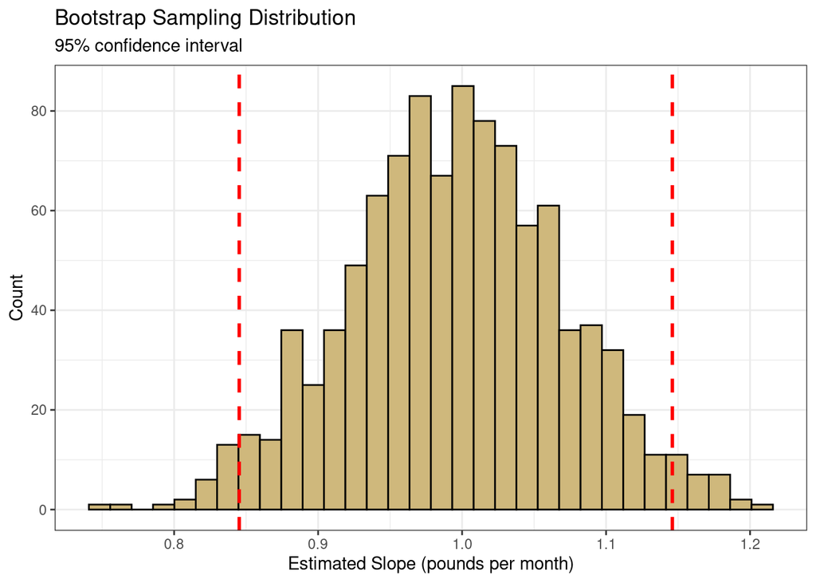

```r
# initiate empty vector
results <- data.frame(slope = rep(NA, 1000))

# repeat resampling 1000 times and save estimated slopes
for (i in 1:1000) {
  set.seed(i)
  rows <- sample(x = nrow(births), size = nrow(births), replace = TRUE)
  resample <- births[rows, ]

  remodel <- lm(weight ~ months, data = resample)
  results$slope[i] <- coefficients(summary(remodel))[2, 1]
}

# plot sampling distribution
ggplot(data = results, aes(x = slope)) +
  geom_histogram(color = "black", fill = "#CFB87C", bins = 32) +
  geom_vline(
    xintercept = quantile(results$slope, probs = 0.025),
    color = "red", linewidth = 1, linetype = "dashed"
  ) +
  geom_vline(
    xintercept = quantile(results$slope, probs = 0.975),
    color = "red", linewidth = 1, linetype = "dashed"
  ) +
  labs(
    title = "Bootstrap Sampling Distribution",
    subtitle = "95% confidence interval",
    x = "Estimated Slope (pounds per month)",
    y = "Count"
  ) +
  theme_bw()
```

The bootstrap sampling distribution appears relatively symmetric, bell-shaped, and centered on a value of 1 pound per month. However, slopes as low as 0.8 or as high as 1.2 are also possible. Based on the bounds (dashed red lines) in the plot, we are 95% confident that the true slope is between about 0.845 and 1.146. Said another way, we are 95% confident that for every additional month of gestation a baby’s birth weight increases by between 0.845 and 1.146 pounds, on average.

# Mathematical Confidence Interval

In the previous section we constructed a confidence interval for the slope parameter using bootstrap resampling. Now we will construct the same interval using the results of the Central Limit Theorem (CLT). In other words, we will assume the sampling distribution for the slope follows a Normal distribution centered on the sample slope ($\hat{\beta}_1$) with the following standard error:

$$SE_{\hat{\beta}_1}= \sqrt{\frac{1}{n-2}\frac{\sum
(y_i-\hat{y}_i)^2}{\sum (x_i-\bar{x})^2}}$$

Given the complexity of the standard error formula, we typically rely on software to complete the calculations. Then we construct a $100 \cdot (1-\alpha)$% confidence interval using the following formula:

$$\hat{\beta}_1 \pm z_{\alpha/2} \cdot SE_{\hat{\beta}_1}$$

Recall that $z_{\alpha/2}$ represents a number of standard errors on the standard Normal distribution. Technically, we should use the t-distribution since the estimation of multiple model parameters introduces additional variability in our estimates. However, for large sample sizes the t-distribution is nearly indistinguishable from the Normal distribution. That said, for small sample sizes we should replace $z_{\alpha/2}$ with $t_{\alpha/2}$.

To demonstrate this approach, we use the same gestation period data set as before. Below we reproduce the summary output from the simple linear regression model.

```r
# display model statistics
coefficients(summary(model))
```

```
##               Estimate Std. Error   t value     Pr(>|t|)
## (Intercept) -1.6673281 0.56027715 -2.975899 2.979145e-03
## months       0.9959822 0.06092158 16.348594 1.881806e-54
```

The summary output provides the mean and standard error for our sampling distribution. Specifically, we have $\hat{\beta}_1=0.996$ and $SE_{\hat{\beta}_1}=0.0609$. We can visualize a 95% confidence interval by simulating a Normal distribution with these parameters.

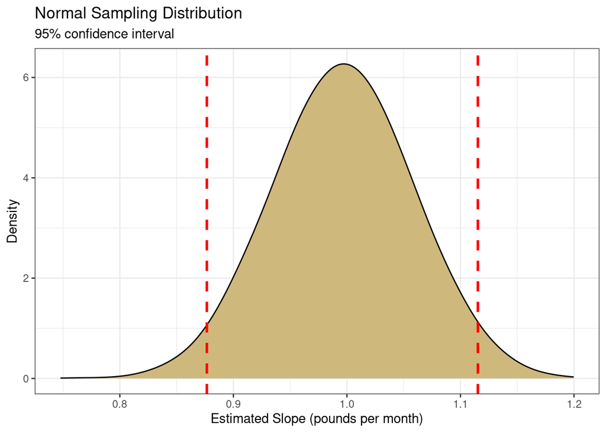

```r
# simulate Normal distribution
set.seed(303)
normal <- data.frame(slope = rnorm(n = 10000, mean = 0.996, sd = 0.0609))

# plot sampling distribution
ggplot(data = normal, aes(x = slope)) +
  geom_density(color = "black", fill = "#CFB87C", adjust = 2) +
  geom_vline(
    xintercept = qnorm(p = 0.025, mean = 0.996, sd = 0.0609),
    color = "red", linewidth = 1, linetype = "dashed"
  ) +
  geom_vline(
    xintercept = qnorm(p = 0.975, mean = 0.996, sd = 0.0609),
    color = "red", linewidth = 1, linetype = "dashed"
  ) +
  labs(
    title = "Normal Sampling Distribution",
    subtitle = "95% confidence interval",
    x = "Estimated Slope (pounds per month)",
    y = "Density"
  ) +
  theme_bw()
```

Alternatively, we can directly compute the bounds of the confidence interval using the formula provided above.

```r
# compute lower bound
0.996 - qnorm(p = 0.975, mean = 0, sd = 1) * 0.0609
```

```
## [1] 0.8766382
```

```r
# compute upper bound
0.996 + qnorm(p = 0.975, mean = 0, sd = 1) * 0.0609
```

```
## [1] 1.115362
```

Whether visually or algebraically, we obtain the same conclusion. We are 95% confident that for every additional month of gestation a baby’s birth weight will increase by between 0.877 and 1.115 pounds, on average. How does this compare to our bootstrap confidence interval?